# Predict DOC from a biogeochemical model output.

Author

Thelma Panaïotis

## Set-up and load data

```r
#|output: false
#|cache: false
source("utils.R")

# Extraction from Nowicki 2022
now <- read_csv("data/raw/Nowicki_pixel_extraction.csv", show_col_types = FALSE)
now <- now %>% mutate(DOC_sample = (DOC_sample * 1000) / 1027.7 ) # convert from mmol C m⁻³ to to µmol C kg⁻¹

# DOC observations from Hansell
obs <- read_csv("data/00.df_doc_obs.csv", show_col_types = FALSE)
```

## Prepare data

### Assemble model output and observations

Row order is supposed to be preserved among model output and observations.

```r
df <- bind_cols(obs, now)
```

Let’s check if binding is OK on depth, lon and lat.

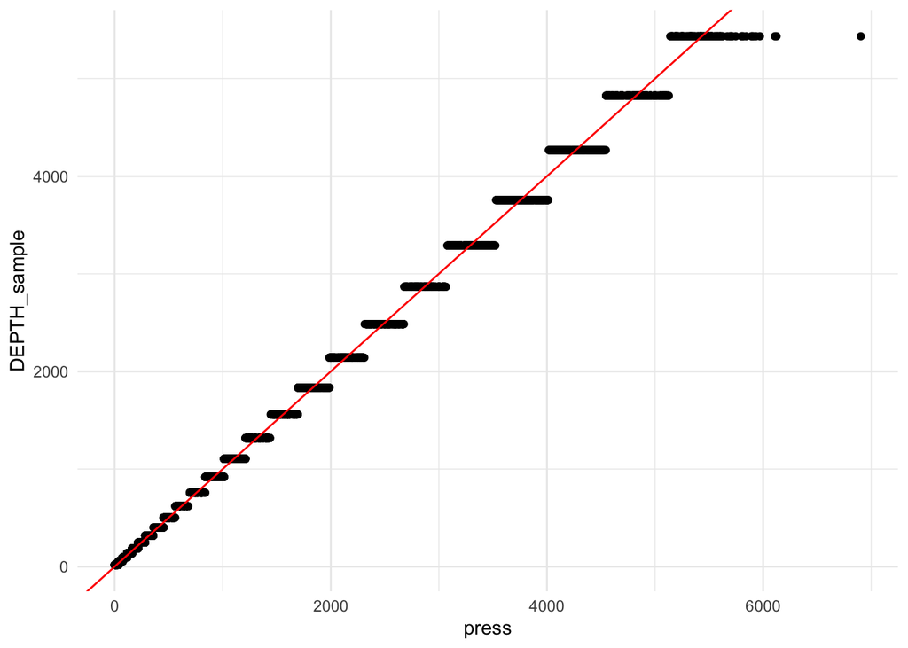

```r
df %>%
  slice_sample(n = 10000) %>%
  ggplot() +
  geom_point(aes(x = press, y = DEPTH_sample)) +
  geom_abline(slope = 1, intercept = 0, colour = "red")
```

OK!

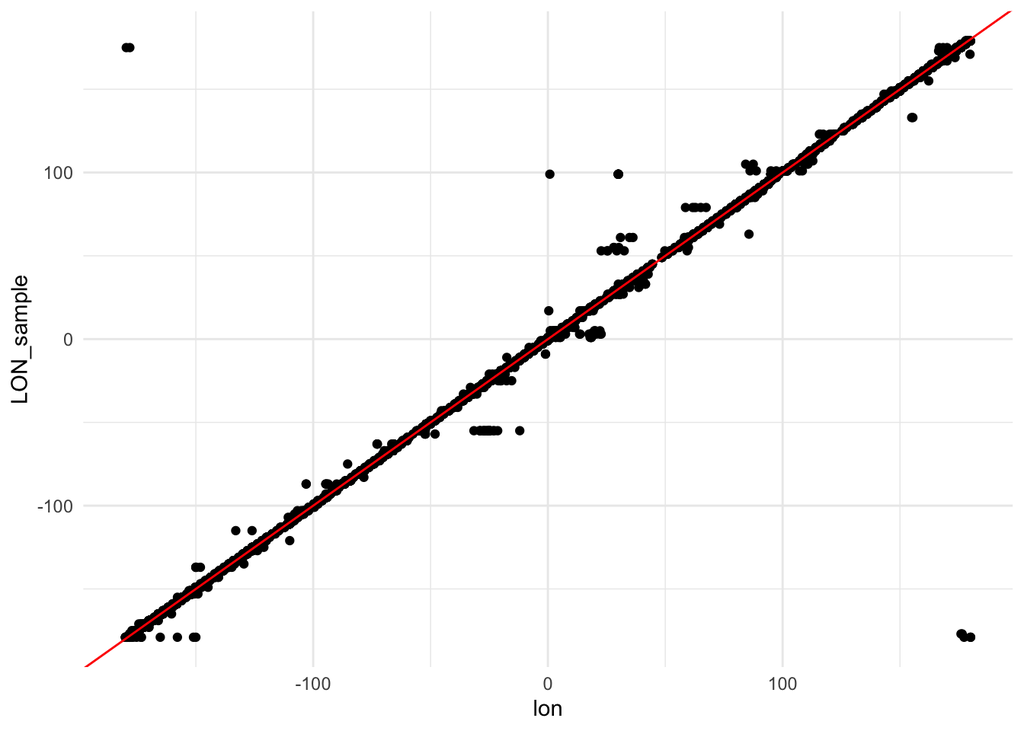

```r
df %>%
  slice_sample(n = 10000) %>%
  ggplot() +
  geom_point(aes(x = lon, y = LON_sample)) +
  geom_abline(slope = 1, intercept = 0, colour = "red")
```

Not OK!

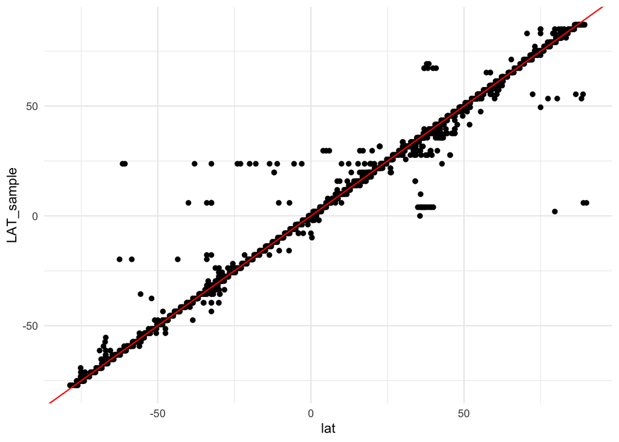

```r
df %>%
  slice_sample(n = 10000) %>%
  ggplot() +
  geom_point(aes(x = lat, y = LAT_sample)) +
  geom_abline(slope = 1, intercept = 0, colour = "red")
```

All points should be on the 1:1 line if match-up was ok. It’s not ok for lon and lat. We need to filter match-ups based on distance between observation and model pixels.

```r
# Compute distance (km) between observation and model point
df <- df %>%
  mutate(dist = geodDist(longitude1 = lon, latitude1 = lat, longitude2 = LON_sample, latitude2 = LAT_sample))
summary(df$dist)
```

```
    Min.  1st Qu.   Median     Mean  3rd Qu.     Max.
    0.00    52.93    80.80   138.40   104.94 12068.20
```

Some distances are very large. Plot distribution.

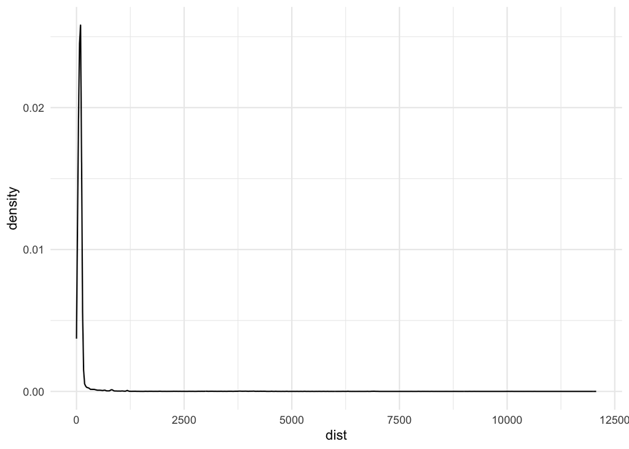

```r
ggplot(df) + geom_density(aes(x = dist))
```

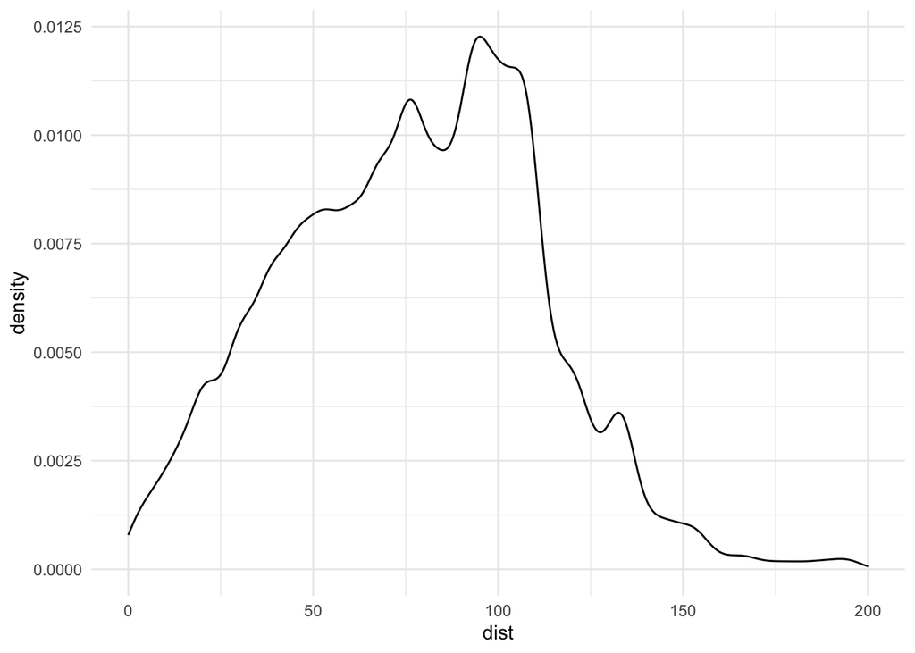

```r
# Let’s zoom in
ggplot(df) + geom_density(aes(x = dist)) + xlim(0, 200)
```

200 km seems a good threshold. Filter distances using a 200 km threshold.

```r
df <- df %>% filter(dist < 200)
```

Let’s now check the filtered match-ups.

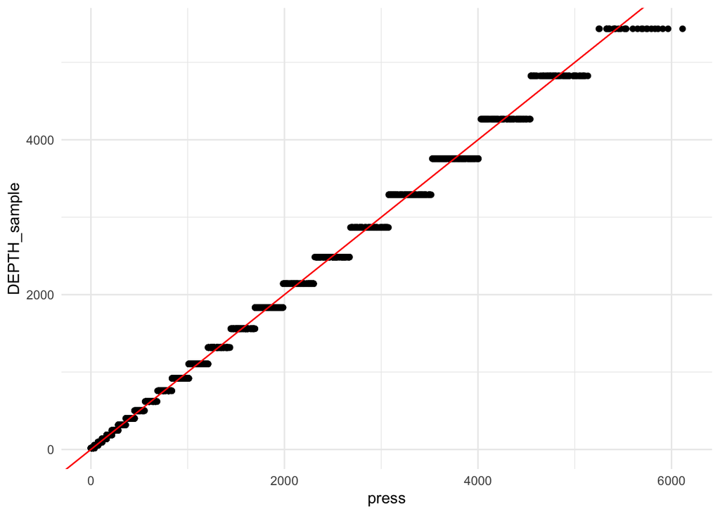

```r
df %>%
  slice_sample(n = 10000) %>%
  ggplot() +
  geom_point(aes(x = press, y = DEPTH_sample)) +
  geom_abline(slope = 1, intercept = 0, colour = "red")
```

OK!

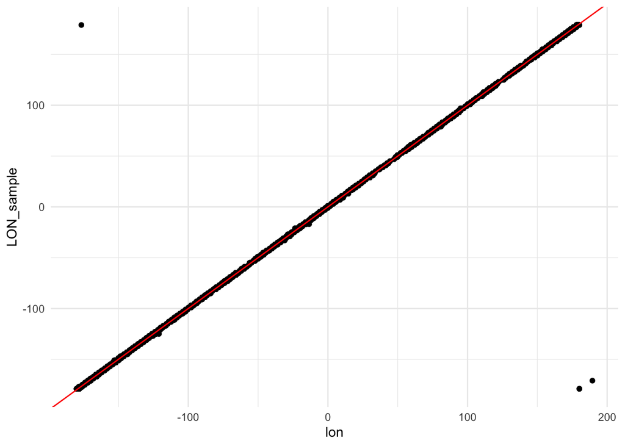

```r
df %>%
  slice_sample(n = 10000) %>%
  ggplot() +
  geom_point(aes(x = lon, y = LON_sample)) +
  geom_abline(slope = 1, intercept = 0, colour = "red")
```

OK!

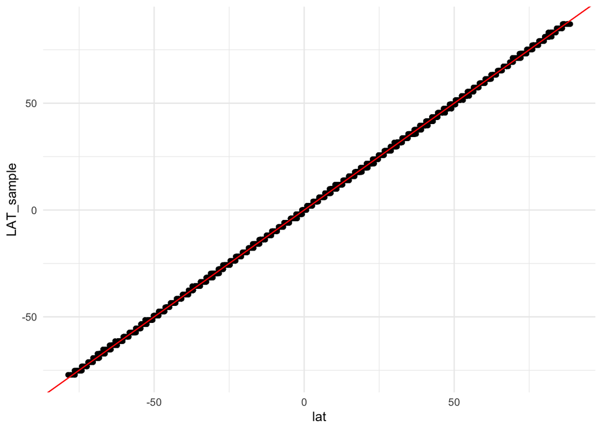

```r
df %>%
  slice_sample(n = 10000) %>%
  ggplot() +
  geom_point(aes(x = lat, y = LAT_sample)) +
  geom_abline(slope = 1, intercept = 0, colour = "red")
```

OK!

### Average by pixel and layer

```r
df <- df %>%
  select(-c(lon, lat, date, press)) %>%
  select(lon = LON_sample, lat = LAT_sample, depth = DEPTH_sample, doc_obs = doc, doc_mod = DOC_sample)

# Assign to layers
df <- df %>%
  mutate(layer = case_when(
    depth <= surface_bottom ~ "surf",
    depth > surface_bottom & depth <= meso_top ~ "epi",
    depth > meso_top & depth <= meso_bottom ~ "meso",
    depth > meso_bottom ~ "bathy",
  )) %>%
  filter(!is.na(layer)) %>% # drop observations not assigned to any layer
  mutate(layer = factor(layer, levels = c("epi", "meso", "bathy"))) # NB: no model outputs for surface layer, i.e. depth < 10 m

# Average by px and by layer
df_pix <- df %>%
  mutate(
    # floor and add 0.5 because other env data are on the centre of each pixel
    lon = roundp(lon, precision = 1, f = floor) + 0.5,
    lat = roundp(lat, precision = 1, f = floor) + 0.5
  ) %>%
  group_by(lon, lat, layer) %>%
  summarise(
    # compute mean and sd
    doc_obs_mean = mean(doc_obs),
    doc_obs_sd = sd(doc_obs),
    doc_mod_mean = mean(doc_mod),
    doc_mod_sd = sd(doc_mod),
    n = n(),
    .groups = "drop"
  )
summary(df_pix)
```

```
      lon               lat           layer       doc_obs_mean
 Min.   :-178.50   Min.   :-77.50   epi  :1808   Min.   : 32.75
 1st Qu.:-135.00   1st Qu.:-31.50   meso :1491   1st Qu.: 41.64
 Median : -32.50   Median : 17.50   bathy:1317   Median : 46.67
 Mean   : -29.89   Mean   : 10.62                Mean   : 53.04
 3rd Qu.:  49.50   3rd Qu.: 47.50                3rd Qu.: 58.71
 Max.   : 179.50   Max.   : 87.50                Max.   :546.26

   doc_obs_sd       doc_mod_mean     doc_mod_sd            n
 Min.   :  0.000   Min.   :35.79   Min.   : 0.0000   Min.   :   1.00
 1st Qu.:  1.489   1st Qu.:39.91   1st Qu.: 0.2179   1st Qu.:   5.00
 Median :  2.991   Median :43.36   Median : 0.8184   Median :  12.00
 Mean   :  4.963   Mean   :45.58   Mean   : 1.8700   Mean   :  20.30
 3rd Qu.:  5.510   3rd Qu.:49.13   3rd Qu.: 2.8125   3rd Qu.:  25.25
 Max.   :174.353   Max.   :92.77   Max.   :16.1448   Max.   :1079.00
 NA's   :243                       NA's   :243
```

Let’s plot a map of observations.

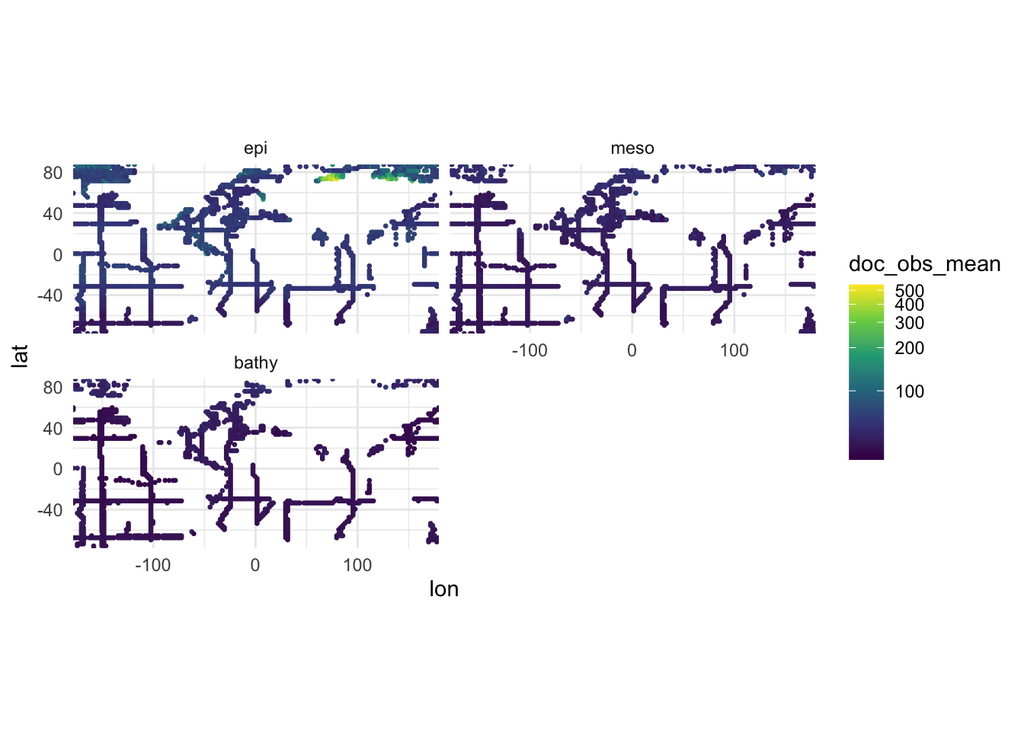

```r
# Map of observations
ggplot(df_pix) +
  geom_point(aes(x = lon, y = lat, colour = doc_obs_mean), size = 0.5) +
  ggplot2::scale_colour_viridis_c(trans = "log1p") +
  coord_quickmap(expand = 0) +
  facet_wrap(~layer, ncol = 2)
```

Let’s plot a map of model output.

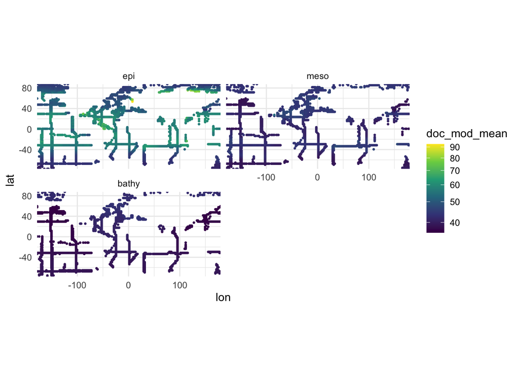

```r
# Map of model_output
ggplot(df_pix) +
  geom_point(aes(x = lon, y = lat, colour = doc_mod_mean), size = 0.5) +
  ggplot2::scale_colour_viridis_c(trans = "log1p") +
  coord_quickmap(expand = 0) +
  facet_wrap(~layer, ncol = 2)
```

And plot observations VS model.

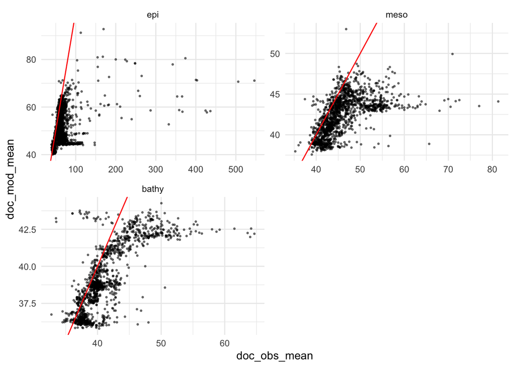

```r
# Plot obs VS mod
ggplot(df_pix) +
  geom_point(aes(x = doc_obs_mean, y = doc_mod_mean), size = 0.5, alpha = 0.5) +
  geom_abline(slope = 1, intercept = 0, colour = "red") +
  facet_wrap(~layer, scales = "free", ncol = 2)
```

Points are not really on the 1:1 line: not a great agreement between model and observations.

Let’s compute R² and RMSE for each layer.

```r
# Compute R² and RMSE for each layer
df_pix %>%
  group_by(layer) %>%
  summarise(
    rsq = rsq_vec(doc_obs_mean, doc_mod_mean),
    rmse = rmse_vec(doc_obs_mean, doc_mod_mean)
  )
```

```
# A tibble: 3 × 3
  layer   rsq  rmse
  <fct> <dbl> <dbl>
1 epi   0.115 38.4
2 meso  0.308  5.65
3 bathy 0.547  3.71
```

The correlation between observations and model output is better for the bathypelagic layer. Let’s focus on this layer only.

```r
df_fit <- df_pix %>% filter(layer == "bathy") %>% select(lon, lat, doc_bathy = doc_mod_mean)
```

Last step before model fitting. Do we need to log-transform the response variable?

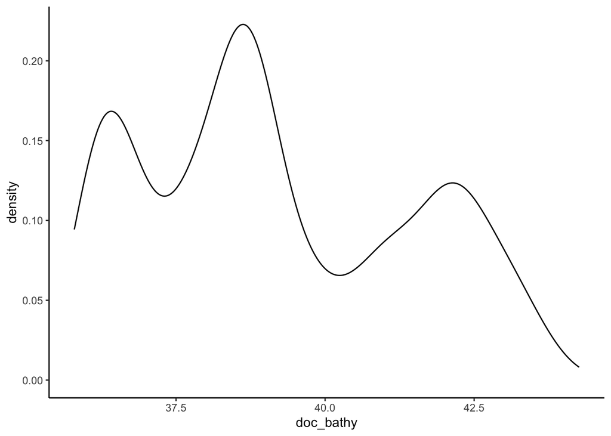

```r
ggplot(df_fit) + geom_density(aes(x = doc_bathy)) + theme_classic()
```

Log-transformation not necessary.

### Assemble with predictors

Let’s assemble our DOC model outputs with environmental predictors from the bathypelagic layer.

```r
load("data/00.all_env.Rdata")
df_env <- df_env %>% rename_all(~ sub("\\.", "_", .x)) # fix column names
df_fit <- df_fit %>%
  left_join(df_env %>% filter(season == 0), join_by(lon, lat)) %>% # assemble with annual env data
  select(-season) %>%
  drop_na()
#rm(df_env) # not needed anymore
```

`df_fit` will be used to fit the model.

### Prepare data for projections

Finally, we also need to prepare data from global projections.

```r
load("data/02.ann_bathy.Rdata")
#rm(df_ann_bathy_fit) # drop the initial data for fitting the model (Hansell obs)
df_pred <- df_ann_bathy_pred %>% select(-season)
```

## Define and fit ML model

### Variable roles

```r
# Response variable
resp_var <- c("doc_bathy") # keep both untransformed and transformed predictor
# Explanatory variables
exp_vars <- df_fit %>% select(temperature_surf:nitrate_bathy) %>% colnames()
# Metadata
meta_vars <- c("lon", "lat")
```

### CV folds

```r
# CV
set.seed(seed)
# Stratified CV on deciles of response variable
folds <- nested_cv(
  df_fit,
  outside = vfold_cv(v = 10, strata = doc_bathy, breaks = 9),
  inside = vfold_cv(v = 10, strata = doc_bathy, breaks = 9)) %>%
  mutate(cv_type = "stratified")
```

### Define model and formula

```r
# Define a xgboost model with hyperparameters to tune
xgb_spec <- boost_tree(
  trees = tune(),
  tree_depth = tune(),
  min_n = tune(),
  learn_rate = tune()
) %>%
  set_mode("regression") %>%
  set_engine("lightgbm")

# Generate formula from list of explanatory variables
xgb_form <- as.formula(paste("doc_bathy ~ ", paste(c(exp_vars), collapse = " + "), sep = ""))
```

### Define grid for gridsearch

```r
# Define one grid for all folds
set.seed(seed)
xgb_grid <- grid_latin_hypercube(
  trees(),
  learn_rate(),
  tree_depth(),
  min_n(),
  size = 30
)
```

### Fit it!

```r
# Fit the model
res <- lapply(1:nrow(folds), function(i){

  message(paste0("Processing fold ", i, " out of ", nrow(folds)))

  ## Get fold
  x <- folds[i,]

  ## Train and test sets
  df_train <- analysis(x$splits[[1]]) %>% as_tibble()
  df_test <- assessment(x$splits[[1]]) %>% as_tibble()

  ## Recipe
  xgb_rec <- recipe(xgb_form, data = df_train)

  ## Workflow
  xgb_wflow <- workflow() %>%
    add_recipe(xgb_rec) %>%
    add_model(xgb_spec)

  ## Gridsearch
  set.seed(seed)
  doParallel::registerDoParallel(n_cores)
  xgb_res <- tune_grid(
    xgb_wflow,
    resamples = x$inner_resamples[[1]],
    grid = xgb_grid,
    metrics = metric_set(rmse),
    control = control_grid(save_pred = TRUE)
  )
  best_params <- select_best(xgb_res)

  ## Final fit
  final_xgb <- finalize_workflow(
    xgb_wflow,
    best_params
  )
  final_res <- fit(final_xgb, df_train)

  ## Prediction on outer folds
  preds <- predict(final_res, new_data = df_test) %>%
    bind_cols(df_test %>% select(doc_bathy, lon, lat))

  ## Predict new data
  new_preds <- augment(final_res, new_data = df_pred) %>%
    rename(pred_doc = .pred) %>%
    relocate(pred_doc, .after = lat)

  doParallel::stopImplicitCluster()

  ## Return results
  return(tibble(
    resp = "doc_bathy",
    cv_type = x$cv_type,
    fold = x$id,
    preds = list(preds),
    new_preds = list(new_preds)
  ))
}) %>%
  bind_rows()
```

## Save results

```r
save(res, file = "data/11a.nowicki_pred.Rdata")
```